# Lab 12: Exploratory Data Analysis

The lab for today has you look at an exploratory analysis in R from two datasets. It introduces a lot of commands for data visualization that we will cover in detail next time.

### Import and view the data

The dataset here shows the number of children born in London on an annual basis, separated by their sex. Interactively in RStudio, you can see the data as a table by clicking on the table in the upper right-hand corner.

```r
births <- read_csv("https://statsmaths.github.io/stat_data/arbuthnot.csv")
```

What years are included in the study?

**Answer**: We have data from 1629 to 1710.

Where/how do you think this data may have been collected?

**Answer**: It was actually collected through church baptism records, by far the most complete record of births in England at the time.

### Plots

Now, let’s visualize the dataset by constructing several different plots. We will learn later how the plotting mechanism actually works. Today just run the code and enjoy.

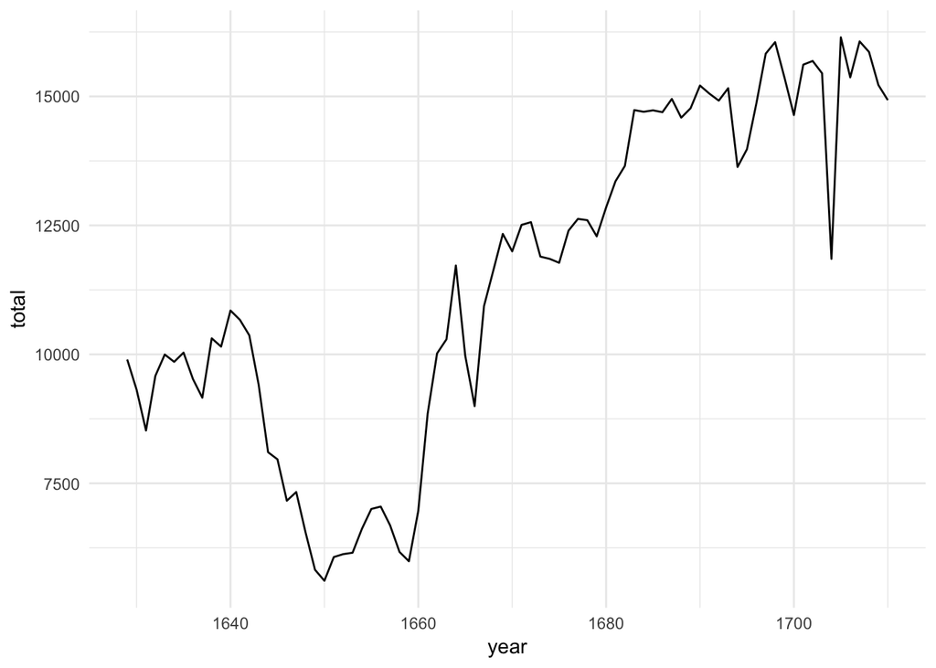

```r
ggplot(births, aes(year, total)) +
  geom_line()
```

Approximately how many children were born in London in 1701?

**Answer**: 15 thousand

What is one change you would like to make to the way R has constructed the plot?

**Answer**: Add better labs for the x and y axes.

Click on the data in the top right hand pane. This will open an Excel like view of the dataset. Describe what the variable `head_of_state` most likely means:

**Answer**: It means who was the head of state of the government in control of London. This changed, rather drastically, throughout the timeperiod of the dataset.

### Variables

You might also have noticed the row of three letter abbreviations under the column names. These describe the type of each variable:

- `int` stands for integers.
- `dbl` stands for doubles, or real numbers.
- `chr` stands for character vectors, or strings.

The types of graphics and data manipulation we can do with a given variable is highly determined by the variable data types.

Explain in words why the variables `boys` and `girls` are interpreted as integers.

**Answer**: These variables are counts and it does not make sense for us to have non-integer numbers here (say, half a person).

### Bar Plot

Create a bar plot of the heads of state:

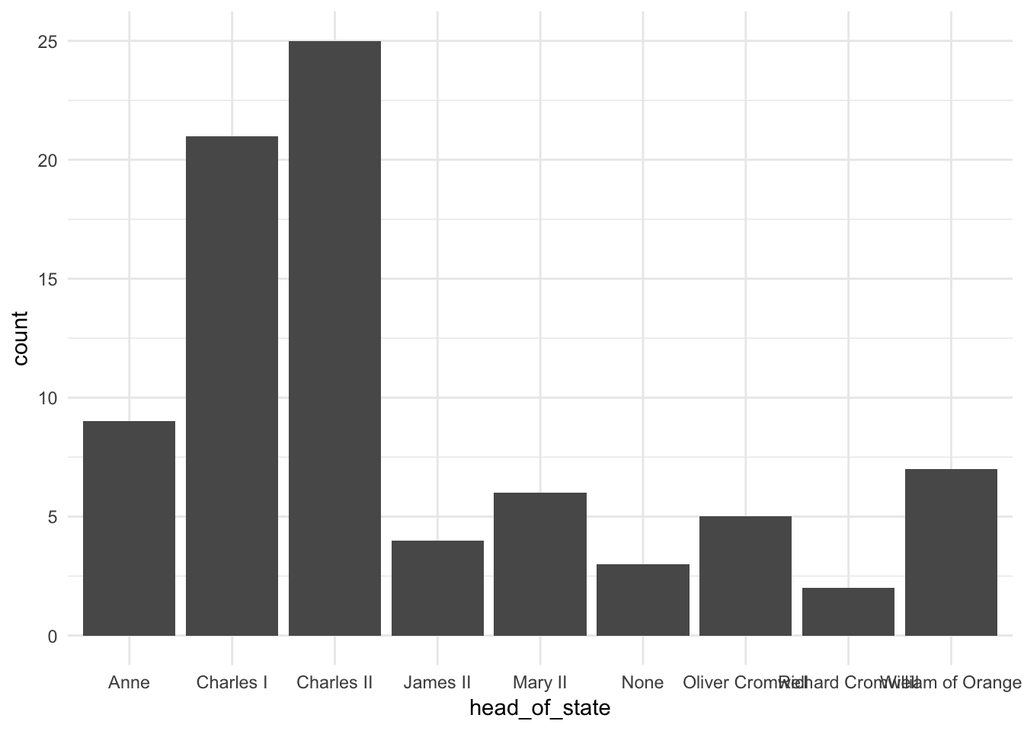

```r
ggplot(births, aes(head_of_state)) +
  geom_bar()
```

Who was the longest serving head of state during the time period of this data set?

**Answer**: Charles II

How are the heads of state arranged be default?

**Answer**: Alphabetically.

### Color

We can add color to the line plot to combine the head of state information with the year and total number of births:

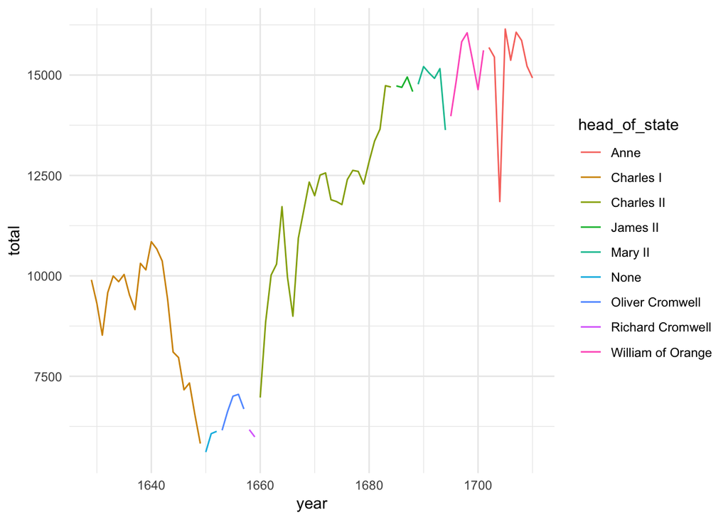

```r
ggplot(births, aes(year, total)) +
  geom_line(aes(color = head_of_state))
```

**Answer**: The Cromwells and “None”, during the period known as the Interregnum (1649-1660).

### Critical thinking

The Arbuthnot data set refers to Dr. John Arbuthnot, an 18th century physician, writer, and mathematician. He gathered the baptism records for children born in London for every year from 1629 to 1710. He was interested in studying what we would now call the **secondary sex ratio**, the ratio of males to females in a population at birth. This would later be a major element of study of Ronald Fisher, one of the most well-known, early pioneering statisticians.

Why would John Arbuthnot be using baptism records to study his question of interest? (Note: I’ll ask you a lot of “thought” questions like this that require critical thinking rather than coding or numerical analysis):

**Answer**: The best source of data at the time.

## Present Day Data

Now, for practice, read in the following dataset with the same information for the present day:

```r
present <- read_csv("https://statsmaths.github.io/stat_data/present.csv")
```

What years are included in this data set?

How do these counts compare to Arbuthnot’s? Are they of a similar magnitude?

**Answer**: The counts are much larger because it is a whole country in the present day rather than just London in the 17th century.

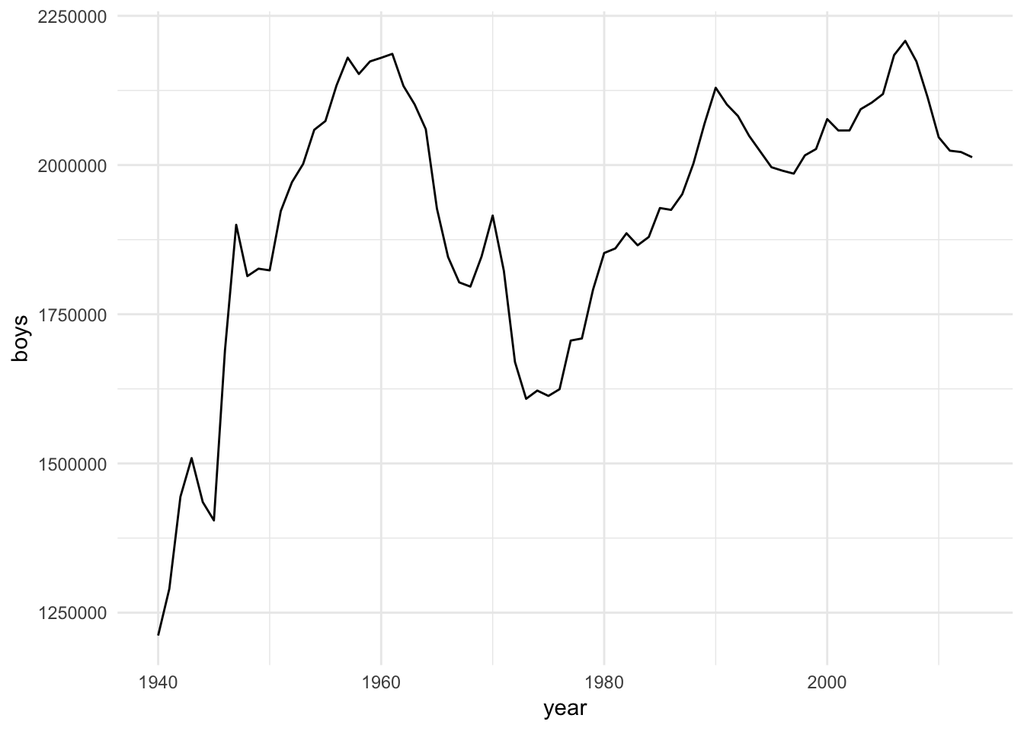

```r
ggplot(present, aes(year, boys)) +
  geom_line()
```

What do you see?

**Answer**: Trends with Baby-Boomers and Echo-Boomers.

In what year did we see the highest total number of births in the U.S.? Note: You’ll need another plot.

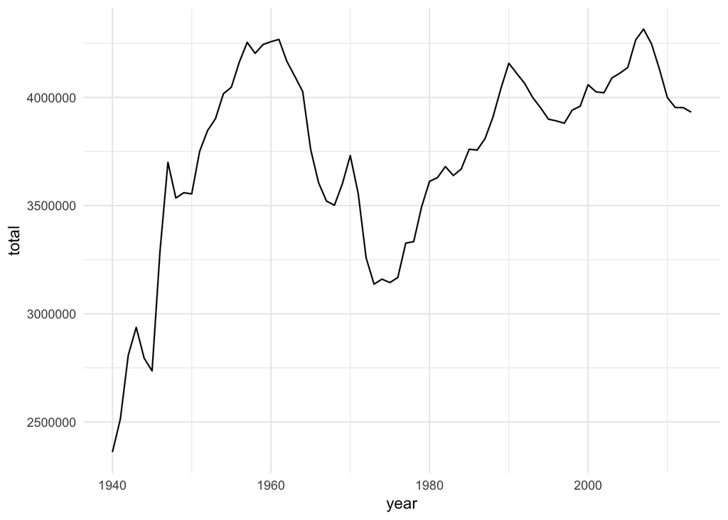

```r
ggplot(present, aes(year, total)) +
  geom_line()
```

**Answer**: The highest looks like either 2007 or 1961 (its the 2007 if you look at the raw numbers, but not by much).

Reconstruct the line plot that is colored by the current head of state.

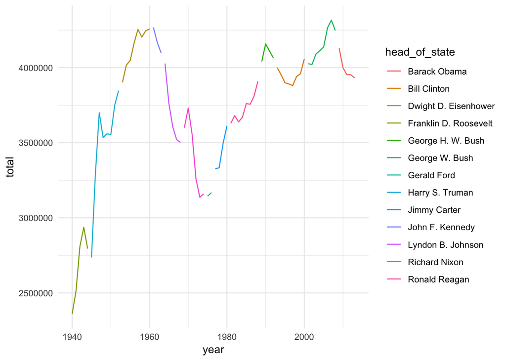

```r
ggplot(present, aes(year, total)) +
  geom_line(aes(color = head_of_state))
```

Do you see any patterns related to particular presidencies? What benefit(s) does including this information add to the plot?

**Answer**: Nothing stands out particularly strongly to me, but it does add context by knowing what time period we are talking about based on who was the president. Personally, I remember the people better than the dates of events.